# Pitch - Covid-19 Prediction App

Ivan Vemado Marques

27/03/2020

# Covid-19 Prediction

This is an web app to try predict a Covid-19 cases and deaths.

The source database of Covid-19 cases and deaths is from ECDC.

Download here: https://www.ecdc.europa.eu/sites/default/files/documents/COVID-19-geographic-disbtribution-worldwide-.

# Navigation Bar

In this menu you can select between **App** and this **Documentation** to acess and explore.

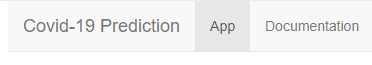

We will show the app functions, but yout can see more of documentation in https://github.com/vemadom/covid19-app.

# App tools

In this panel you can select some atributes of charts.

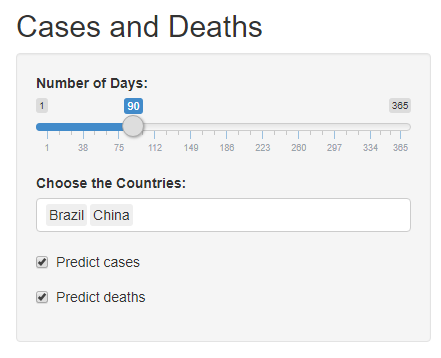

Here you have some input tools to adjust the predictions:

- Slide: To select range of days of observation.
- Box: To choose countries to compare in the charts.
- Modelling Option:
  1. Predict cases: to plot predict curves of observed cumulative cases for each country selected in the cases chart.
  2. Predict deaths: to plot predict curves of observed cumulative deaths for each country selected in the deaths chart.

# Predictions

This is an example chart of prediction cases. It shows two features howlong days stats first contamination in the world (in China):

- Points: is a plot of points of cumulative Covid-19 cases for each country filtered (or deaths, you choose by **Tab** menu)
- Lines: is a model by “loess” method to fit a best curve to predict the evolution of cumulative Covid-19 cases for each country filtered (or deaths, you choose by **Tab** menu)

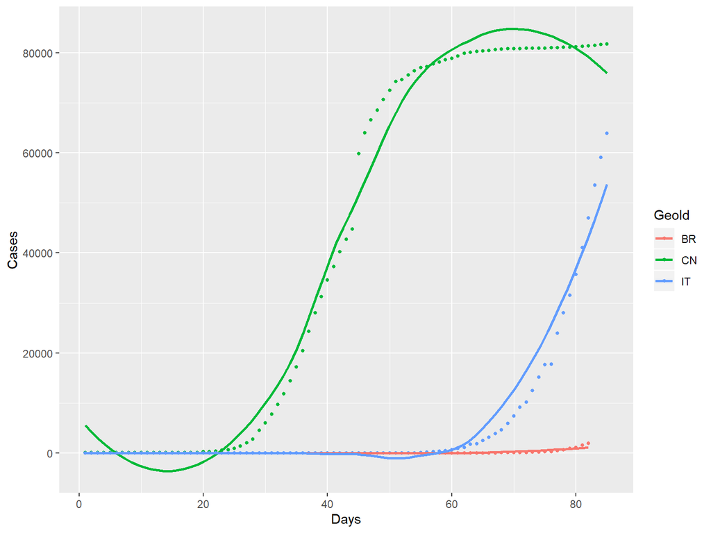

```r
ggplot(subset(df_all, df_all$Countries.and.territories %in% c("China", "Brazil", "Italy")),
       aes(x=days_all, y=cases_all, col=GeoId)) +
  labs(y = "Cases", x = "Days") +
  geom_point(size = 1.0) +
  geom_smooth(method = "loess", formula = y~x, se = FALSE)
```